# Anomaly Detection for Equine Gait Abnormalities

INFO 523 - Final Project

Unsupervised learning techniques were used to detect equine exercise sessions exhibiting gait abnormalities, providing an objective means of identifying subtle movement changes that may be missed by visual evaluation.

Author

Affiliation

Ashley Sodt

Applied Math PhD Student, University of Arizona

## Abstract

Unsupervised learning techniques were used to detect equine exercise sessions exhibiting gait abnormalities, providing an objective means of identifying subtle movement changes that may be missed by visual evaluation. Movement-based features derived from processed EquiPro accelerometer data were analyzed, including biomechanical metrics such as diagonal advanced placement, stride duration, and footfall duration. Typical movement patterns for each horse were modeled so that sessions deviating significantly from baseline could be identified. Through this approach, anomalies that may indicate injury risk, reinjury susceptibility, or underlying pain or discomfort were detected. This project was motivated by the need for an objective approach to detect subtle gait changes beyond what visual observation can capture.

## Introduction

I work under Dr. Laura Miller, whose recent projects involve work at the Al-Marah Equine Center owned by the University. Our team collects gait analysis data using EquiPro accelerometers during lunging exercise sessions. Seven accelerometer sensors are placed on the horse in key anatomical locations (each leg, head, withers, and sacrum) while the horse is exercised on a lunge line at a walk, trot, and canter. The EquiPro system then computes stride-level biomechanical metrics such as diagonal advanced placement and stride duration.

By modeling typical movement patterns for three selected horses, I aim to identify anomalous exercise sessions that deviate significantly from a horse’s baseline. Such anomalies may reflect early indicators of injury risk, reinjury susceptibility, or underlying pain or discomfort. This makes anomaly detection a valuable tool for proactive performance monitoring, enabling the identification of subtle gait changes before clear signs of injury are apparent.

## Methods

For this project, I focused exclusively on trot strides. The trot is a highly symmetric gait which makes deviations easier to detect but more importantly, mixing gaits would introduce variability unrelated to movement abnormalities. For each exercise session, I loaded the corresponding EquiPro CSV file and extracted stride-level biomechanical variables related to timing, symmetry, and limb loading mechanics:

**Stride Metrics (3)**

- `stride_dur`: time to complete one full stride
- `stride_speed`: forward velocity of the horse during a stride
- `stride_length`: distance covered by the horse in one stride

**Limb Loading and Timing (9)**

- `duty_factor`: overall proportion of the stride spent in ground contact
- `duty_factor_LF / duty_factor_RF`: proportion of stride spent in stance for the left and right forelimbs
- `duty_factor_LH / duty_factor_RH`: proportion of stride spent in stance for the left and right hindlimbs
- `stance_dur_LF / stance_dur_RF`: time the left and right front hooves remain in contact with the ground
- `stance_dur_LH / stance_dur_RH`: time the left and right hind hooves remain in contact with the ground

**Coordination (4)**

Diagonal Advanced Placement (DAP) describes the relative timing between diagonal limb pairs during the trot. It reflects how coordinated the diagonal limbs are within each stride.

- `dap_L_sec / dap_R_sec`: diagonal advanced placement timing between limb pairs (LF–RH, RF–LH), measured in seconds
- `dap_L_perc / dap_R_perc`: diagonal advanced placement timing expressed as a percentage of the stride

**Trunk Symmetry and Balance (9)**

- Head:
  - `min_diff_head`: minimum vertical displacement difference between left and right loading phases
  - `max_diff_head`: maximum vertical displacement difference between left and right loading phases
  - `si_up_head`: symmetry index describing upward head movement balance
- Withers:
  - `min_diff_wth`: minimum vertical displacement difference at the withers
  - `max_diff_wth`: maximum vertical displacement difference at the withers
  - `si_up_wth`: symmetry index describing withers movement balance
- Sacrum:
  - `min_diff_sac`: minimum vertical displacement difference at the sacrum
  - `max_diff_sac`: maximum vertical displacement difference at the sacrum
  - `si_up_sac`: symmetry index describing pelvic movement balance

**Total stride-level variables:** 25

To create session-level features, I summarized each variable using mean, standard deviation, and interquartile range. These statistics capture different ways a session can deviate from a horse’s typical movement pattern, as no single metric can fully describe gait behavior across an entire exercise session. As the analysis considers distributions of strides within a session rather than individual strides, these summary statistics are essential. For example, consider the right hind stance duration during the trot strides of one session:

- **Mean**: indicates whether the horse is consistently loading the right hind more or less than usual across the session
- **Standard deviation**: captures if the stance duration is changing significantly from stride to stride
- **Interquartile range**: measures if there are many strides behaving differently, not just a couple

These transformations converted raw stride-by-stride data into session-level behaviors. In all, the session-level feature matrix contained 24 total exercise sessions each with 75 engineered biomechanical features.

I then focused on modeling each horse’s baseline movement patterns. All features were standardized within each horse by first converting them to z-scores in order to remove scale differences. This provided a clear reference point for typical movement behavior: features consistently close to zero after standardization indicated typical behavior, but large positive or negative values indicate potential deviations. These standardized distributions formed the baseline against which the anomaly detection methods evaluated whether any given session departs significantly from a horse’s typical movement pattern.

After establishing the baselines for each horse using z-scores, I applied three unsupervised anomaly detection methods to identify sessions that deviate from typical movement. Z-score analysis allowed me to flag sessions where specific features were unusually high or low relative to baseline distribution. K-means clustering identified anomalies based on their distance from cluster centers in the multivariate feature space. Isolation forest gave a measure of how isolated a session was from the rest. Each method identified sessions as anomalous based on its own criteria, allowing comparison of agreement across methods and identification of high-confidence anomalies.

I want to disclose that AI was used to help with code development and debugging.

## Results

Different anomaly detection methods flagged a different number of sessions for each horse. Z-score thresholding identified relatively few anomalies and flagged sessions only for Duque. In contrast, K-means distance and Isolation Forest flagged more sessions across horses. By construction, this could be due to their ability to capture multivariate deviations from typical patterns. Duque had the highest number of anomalous sessions across all methods, while Perseo was flagged only by the K-means method, likely due to the small number of sessions.

To identify the most likely anomalies, sessions flagged by at least two anomaly detection methods were classified as high-confidence anomalies. A small subset of five sessions met this criteria. One of Duque’s sessions was flagged by all three methods. The remaining high-confidence sessions were flagged by two methods: two of which were Duque sessions, two of which were Jackson sessions. A method agreement heatmap was created to further show this overlap, reinforcing the idea that agreement across methods give us more confidence that these sessions reflect meaningful deviations from typical movement patterns.

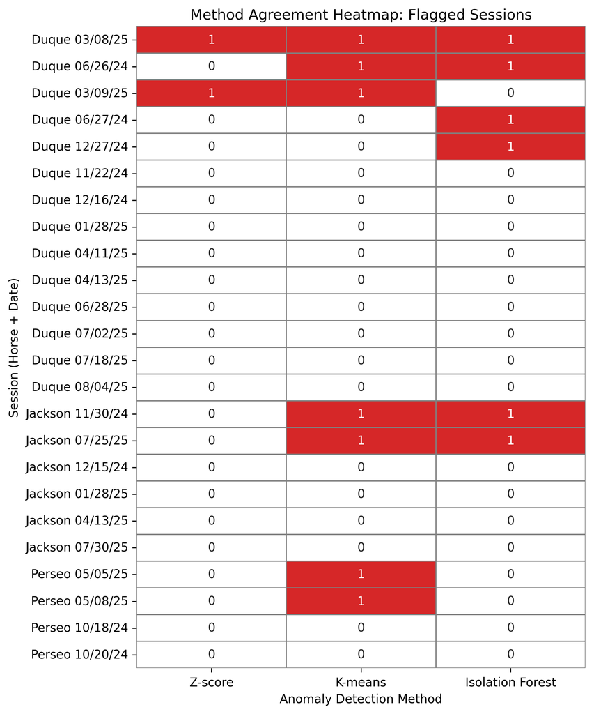

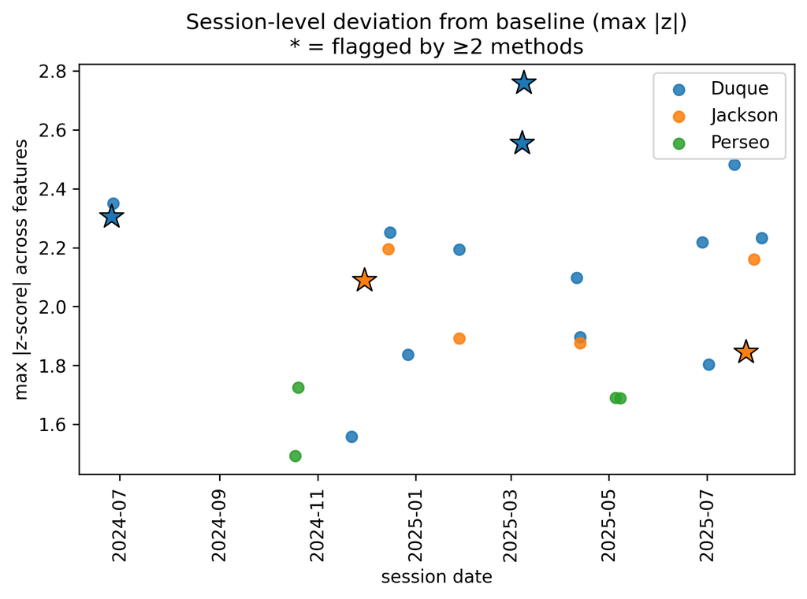

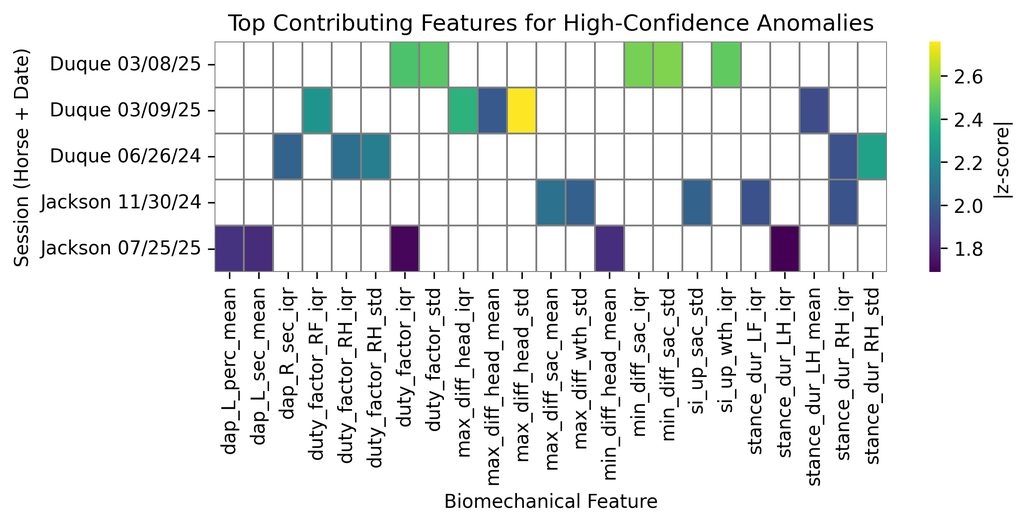

The results we found are informative, but several limitations should be acknowledged. The number of exercise sessions available per horse was relatively small. This impacts the baseline estimates and reduces the effectiveness of the unsupervised anomaly detection methods. Also, external factors such as the environment, rider influence, and equipment are not factored into the data and may contribute to metric variability. The final limitation acknowledged is that the analysis assumes each horse’s baseline gait remains stable over time. In practice this assumption may not hold as training, conditioning, or therapeutic interventions could naturally change a horse’s gait, independent of injury or abnormality.

## Conclusion

In this project, we constructed horse-specific baseline gait profiles using session-level biomechanical features from stride-level EquiPro data. Unsupervised anomaly detection methods including z-score thresholding, k-means clustering, and isolation forest were applied to identify sessions that deviated from each horse’s typical movement pattern. Many sessions showed minor variation, but only a small subset demonstrated strong evidence of abnormality, defined as sessions flagged by at least two detection methods. For these high-confidence anomalies, examining feature-level z-scores helped identify which biomechanical variables contributed most to deviation. This enables interpretation and insight into the potential cause of gait changes during each flagged session. Overall, this approach shows that anomaly detection can reveal subtle, horse-specific gait abnormalities that may reflect injury risk, reinjury susceptibility, or underlying pain or discomfort. As a result, it supports earlier and more informed intervention before clear signs of injury emerge.